# R Markdown Hints

Think of an `R Markdown File`, or `Rmd` for short, as a command center. You write commands, then Knit the file, and an html output file is created according to your commands.

### Hide Cheatsheet

The above tabs were created with the code:

```
## {.tabset .tabset-pills .tabset-fade}

### Hide Cheatsheet

### Show

Text and image were placed here...
```

### Show

Carefully read through all parts of this image to learn…

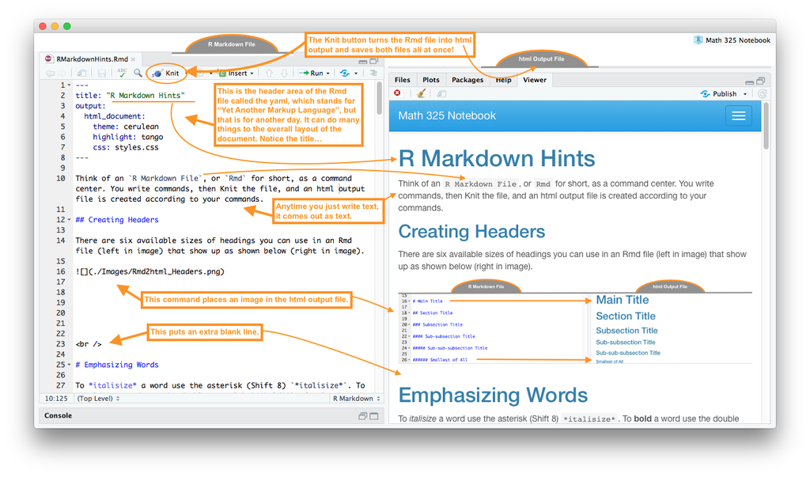

## Creating Links

To make a link use the code `[Name of Link](addressForLink)`.

Linking to parts of your textbook:

- `[Numerical Summaries](NumericalSummaries.html)` *becomes* Numerical Summaries
- `[Boxplots](GraphicalSummaries.html#boxplots)` *becomes* Boxplots
- `[R Commands](RCommands.html)` *becomes* R Commands

Linking to outside resources:

- `[R Colors](http://www.stat.columbia.edu/~tzheng/files/Rcolor.pdf)` *becomes* [R Colors](http://www.stat.columbia.edu/~tzheng/files/Rcolor.pdf)

## Creating Headers

There are six available sizes of headings you can use in an Rmd file (left in image) that show up as shown below (right in image).

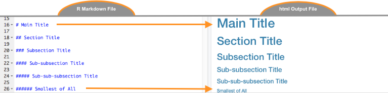

# Emphasizing Words

# Bullet Points

#### Simple Lists

To achieve the result:

- This is the first item.
- This is the second.
- This is the third.

Use the code:

```r
To achieve the result:

* This is the first item.

* This is the second.

* This is the third.
```

#### Numbered Lists

To achieve the result:

1. This is the first item.
2. This is the second.
3. This is the third.

Use the code:

```r
To achieve the result:

1. This is the first item.

2. This is the second.

3. This is the third.
```

#### Lettered Lists

Use the code:

```r
To achieve the result:

A) This is the first item.

B) This is the second.

C) This is the third.
```

#### Nested Lists

1. What is $2+2$?
   1. **4**
   2. 8
2. What is $3\times5$?
   1. 14
   2. **15**

```r
1. What is $2+2$?

    a. **4**

    b. 8

2. What is $3\times5$?

    a. 14

    b. **15**
```

# Math Equations

Use the dollar signs `$x=5$` to write $x=5$ or `$z=\frac{x-\mu}{\sigma}$` to write $z=\frac{x-\mu}{\sigma}$. For a nicely centered equation use the double dollar signs `$$ $$` on separate lines

```r
$$
  z = \frac{\bar{x}-\mu}{\frac{\sigma}{\sqrt{n}}}
$$
```

to get
$$z = \frac{\bar{x}-\mu}{\frac{\sigma}{\sqrt{n}}}$$

Or

```r
$$
  H_0: \mu_1 = \mu_2
$$
$$
  H_a: \mu_1 \neq \mu_2
$$
```

Symbol list:

| Symbol | LaTeX Math Code |
| --- | --- |
| $\alpha$ | `$\alpha$` |
| $\beta$ | `$\beta$` |
| $\sigma$ | `$\sigma$` |
| $\epsilon$ | `$\epsilon$` |
| $\bar{x}$ | `$\bar{x}$` |
| $\hat{Y}$ | `$\hat{Y}$` |
| $=$ | `$=$` |
| $\ne$ | `$\ne$` or `$\neq$` |
| $>$ | `$>$` |
| $<$ | `$<$` |
| $\ge$ | `$\ge$` |
| $\le$ | `$\le$` |
| $\{ \}$ | `$\{ \}$` |
| $\text{Type just text}$ | `$\text{Type just text}$` |
| $\overbrace{Y_i}^\text{label}$ | `$\overbrace{Y_i}^\text{label}$` |
| $\underbrace{Y_i}_\text{label}$ | `$\underbrace{Y_i}_\text{label}$` |

# Insert a Picture

To add a picture to your document, say some notes you took down on paper from class,

Use the code: `![](./Images/insertPictureNotes.jpg)` to get…

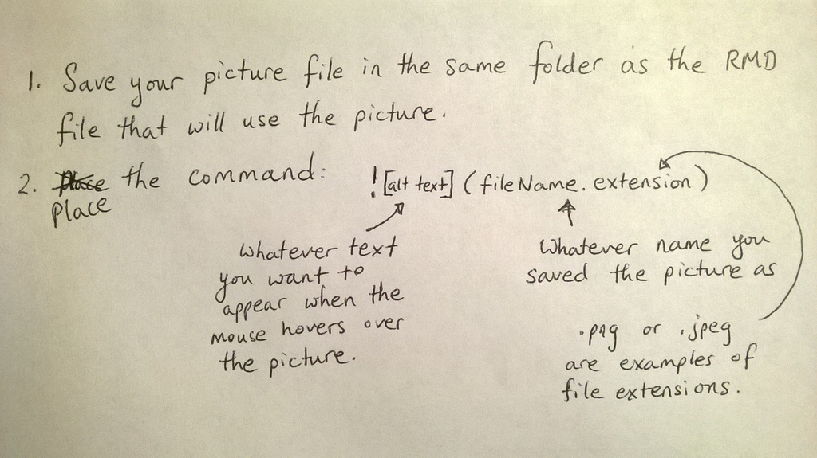

# Tables

There are many ways to [make tables](http://rmarkdown.rstudio.com/authoring_pandoc_markdown.html#tables) in R Markdown. Here is a simple way to make a “pipe” table.

```r
| Name          | Age           | Gender       |
|---------------|---------------|--------------|
| Jill          | 8             |  Female      |
| Jack          | 9             |  Male        |
```

| Name | Age | Gender |
| --- | --- | --- |
| Jill | 8 | Female |
| Jack | 9 | Male |

# Themes

Notice in the YAML (at the top of the RMD file) there is a line that reads:

“theme: cerulean”

Other possible themes are

- “default”, “cerulean”, “journal”, “flatly”, “readable”, “spacelab”, “united”, and “cosmo”.

You can also change the `highlighting` by adding the line “highlight: tango” to the YAML as follows.

```r
---
title: "Markdown Hints"
output:
  html_document:
    theme: cerulean
    highlight: tango
---
```

Other highlighting options are

- “default”, “tango”, “pygments”, “kate”, “monochrome”, “espresso”, “zenburn”, “haddock”, and “textmate”.

# More Information

Go to the [rmarkdown.rstudio.com](http://rmarkdown.rstudio.com/html_document_format.html) website for more information on how to use R Markdown.